# Modeling/Predicting the Growth of Bike Sharing Services in DC

Wenxuan Yu

### Introduction:

Because of the dominant role of Capital Bikeshare in the bike-sharing market, this model would reflect the overall growth of all bike-sharing services in DC. After having our 7 years of data cleaned up, we will use tools to predict the growth rate of the market and test our prediction using later years' data.

### Data Collection:

The data we are using comes from the Capital Bikeshare database. The same data can be found at this link, under “Trip History Data”: https://ride.capitalbikeshare.com/system-data We are analyzing the data from 2010 to 2017 for this part of the tutorial.

The data includes these attributes:

- Duration – Duration of trip
- Start Date – Includes start date and time
- End Date – Includes end date and time
- Start Station – Includes starting station name and number
- End Station – Includes ending station name and number
- Bike Number – Includes ID number of bike used for the trip
- Member Type – Indicates whether the user was a "registered" member (Annual Member, 30-Day Member, or Day Key Member) or a "casual" rider (Single Trip, 24-Hour Pass, 3-Day Pass, or 5-Day Pass)

The data has been processed to remove trips that are taken by staff as they service and inspect the system, trips that are taken to/from any of the “test” stations at the Capital Bikeshare warehouses, and any trips lasting less than 60 seconds (potentially false starts or users trying to re-dock a bike to ensure it's secure).

```python
import pandas as pd
import os
```

### Tools:

- pandas
  - This Python library called pandas will be the essential tool we use to extract, store, and manipulate data. The data will be extracted from the CSV files, and stored in a DataFrame, which provides easy manipulation of the data. More information can be found here: https://pandas.pydata.org/pandas-docs/stable/reference/api/pandas.DataFrame.html
- os
  - This library is used here to simplify the data extraction process, which is transforming the data from the CSV files to pandas DataFrame. Because we have many CSV files for every year, it would be inefficient to manually enter the file names. Therefore, I used functions in the os library to automate the process. More information about the os library can be found here: https://docs.python.org/3.7/library/os.html

```python
# Because we have every year's data in one file, some years' data is even divided into 4 files (Q1-Q4),
# we are using functions from os library to put all filenames into a list, instead of manually typing them.
file_names = ["./data/" + f for f in os.listdir('./data') if f.endswith('.csv')]
data = pd.concat(map(pd.read_csv, file_names))
# These are the names for all our data.
file_names
```

```
['./data/2010.csv',
 './data/2011.csv',
 './data/2012Q1.csv',
 './data/2012Q2.csv',
 './data/2012Q3.csv',
 './data/2012Q4.csv',
 './data/2013Q1.csv',
 './data/2013Q2.csv',
 './data/2013Q3.csv',
 './data/2013Q4.csv',
 './data/2014Q1.csv',
 './data/2014Q2.csv',
 './data/2014Q3.csv',
 './data/2014Q4.csv',
 './data/2015Q1.csv',
 './data/2015Q2.csv',
 './data/2015Q3.csv',
 './data/2015Q4.csv',
 './data/2016Q1.csv',
 './data/2016Q2.csv',
 './data/2016Q3.csv',
 './data/2016Q4.csv',
 './data/2017Q1.csv',
 './data/2017Q2.csv',
 './data/2017Q3.csv',
 './data/2017Q4.csv']
```

```python
# Checking all the attributes (columns) of the data, the names are explainatory.
data.head()
```

|  | Duration | Start date | End date | Start station number | Start station | End station number | End station | Bike number | Member type |
| --- | --- | --- | --- | --- | --- | --- | --- | --- | --- |
| 0 | 1012 | 2010-09-20 11:27:04 | 2010-09-20 11:43:56 | 31208 | M St & New Jersey Ave SE | 31108 | 4th & M St SW | W00742 | Member |
| 1 | 61 | 2010-09-20 11:41:22 | 2010-09-20 11:42:23 | 31209 | 1st & N St SE | 31209 | 1st & N St SE | W00032 | Member |
| 2 | 2690 | 2010-09-20 12:05:37 | 2010-09-20 12:50:27 | 31600 | 5th & K St NW | 31100 | 19th St & Pennsylvania Ave NW | W00993 | Member |
| 3 | 1406 | 2010-09-20 12:06:05 | 2010-09-20 12:29:32 | 31600 | 5th & K St NW | 31602 | Park Rd & Holmead Pl NW | W00344 | Member |
| 4 | 1413 | 2010-09-20 12:10:43 | 2010-09-20 12:34:17 | 31100 | 19th St & Pennsylvania Ave NW | 31201 | 15th & P St NW | W00883 | Member |

### Data Cleaning:

At this part of the tutorial, we will do our best to “fix-up” the data. After the process, the data should be organized so that it is readable and easy to analyze. We will achieve this by manipulating our DataFrame’s columns and rows.

```python
# Because we want to hold the original data, we will do all our processing with data_cp!
data_cp = data

# Checking every columns' type
# We realize "Start date" and "End date" are not DateTime Objects. We will change them!
data_cp.dtypes
```

```
Duration                 int64
Start date              object
End date                object
Start station number     int64
Start station           object
End station number       int64
End station             object
Bike number             object
Member type             object
dtype: object
```

In our case of bike-sharing data, the first thing we realize is our “Start date” and “End date” columns are not DateTime objects, which is a type of object that gives us easy access to the year, month, date, and time of the data. We will transform the two columns with pandas.to_datetime function.

After that, to identify which year is each row representing, we will extract the year from "Start date" column for every row, and create a new column showing us the year. This will also make actions like grouping data by year easier later. Finally, we will create new columns “Day”, "Hour", and “Month” to indicate the data’s day of week, hour, and month. All these extra data will come in handy later when we try to analyze what day of the week people use bike-sharing services the most, for example, easier. We can always add more columns if needed later.

More information about DateTime can be found here: https://docs.python.org/3/library/datetime.html

More information about pandas.to_datetime can be found here: https://pandas.pydata.org/docs/reference/api/pandas.to_datetime.html

```python
# We are converting 'Start date' and 'End date' columns to pandas DateTime objects. This way we can extract year, month, day, and time easily.
data_cp['Start date'] = pd.to_datetime(data_cp['Start date'])
data_cp['End date'] = pd.to_datetime(data_cp['End date'])
# Now we are adding a column called 'Year' to our DataFrame, so we can group our data by year easily.
data_cp['Year'] = pd.DatetimeIndex(data_cp['Start date']).year
# Adding the "Day" column indicating day-of-week
data_cp['Day'] = data['Start date'].dt.day_name()
# Adding the "Hour" column indicating hour of the day
data_cp['Hour'] = data['Start date'].dt.hour
# Adding the "Month" column indicating month
data_cp['Month'] = data['Start date'].dt.month
```

```python
data_cp.head()
```

|  | Duration | Start date | End date | Start station number | Start station | End station number | End station | Bike number | Member type | Year | Day | Hour | Month |
| --- | --- | --- | --- | --- | --- | --- | --- | --- | --- | --- | --- | --- | --- |
| 0 | 1012 | 2010-09-20 11:27:04 | 2010-09-20 11:43:56 | 31208 | M St & New Jersey Ave SE | 31108 | 4th & M St SW | W00742 | Member | 2010 | Monday | 11 | 9 |
| 1 | 61 | 2010-09-20 11:41:22 | 2010-09-20 11:42:23 | 31209 | 1st & N St SE | 31209 | 1st & N St SE | W00032 | Member | 2010 | Monday | 11 | 9 |
| 2 | 2690 | 2010-09-20 12:05:37 | 2010-09-20 12:50:27 | 31600 | 5th & K St NW | 31100 | 19th St & Pennsylvania Ave NW | W00993 | Member | 2010 | Monday | 12 | 9 |
| 3 | 1406 | 2010-09-20 12:06:05 | 2010-09-20 12:29:32 | 31600 | 5th & K St NW | 31602 | Park Rd & Holmead Pl NW | W00344 | Member | 2010 | Monday | 12 | 9 |
| 4 | 1413 | 2010-09-20 12:10:43 | 2010-09-20 12:34:17 | 31100 | 19th St & Pennsylvania Ave NW | 31201 | 15th & P St NW | W00883 | Member | 2010 | Monday | 12 | 9 |

Checking Missing Data

After adding the columns we need, we will check if there are any missing data (e.g. NaN). If NaN exist for any columns, we would drop them in our case, because it makes that row of data useless. However, we are lucky that there is no NaN value presented!

```python
# Checking for NaN value!
nan_in_df = data_cp.isnull().sum().sum()
# printing the number of values present in
# the whole dataframe
print('Number of NaN values present: ' + str(nan_in_df))

# We are done cleaning data!
```

```
Number of NaN values present: 0
```

### Data Analysis:

In this part of the tutorial, we aim to gain comprehensive knowledge of our data, using tools like different plots/graphs to visualize it.

We will be visualizing:

- The total number of bike-sharing between 2010 - 2017
- The number of “registered” members between 2010 - 2017
- Where are the top used stations/locations located? 2010 - 2017
- The total number of bikes shared on each day of the week
- The total number of bikes shared in each hour of the day
- The total number of bikes shared in each month of the year

Tools:

- pandas.DataFrame.groupby() function, which groups the data in a data frame with given parameters, such as column names. Heavily used when extracting year, month, week, and day data. More information can be found here: https://pandas.pydata.org/docs/reference/api/pandas.DataFrame.groupby.html
- ax.plot() function, which returns a line plot of given independent and dependent variables. More information can be found here: https://matplotlib.org/3.5.0/api/_as_gen/matplotlib.axes.Axes.plot.html
- ax.bar() function, which returns a bar graph with given categories and corresponding data. More information here: https://matplotlib.org/3.5.0/api/_as_gen/matplotlib.axes.Axes.bar.html
- folium library, which is a python library that provides easy means to create an interactive map. More information can be found here: https://towardsdatascience.com/creating-a-simple-map-with-folium-and-python-4c083abfff94

```python
import matplotlib.pyplot as plt
```

```python
graph_data = data_cp
# We add a column called count so when we are doing grouping we can easily see how many are there
graph_data['count'] = 1

### Graphing the total number of bike sharing between 2010 and 2017 ###

# Grouping the data by year and summing it so we get the number of data each year
total_number_data = graph_data.groupby(['Year']).sum()
total_number_data
```

| Year | Duration | Start station number | End station number | Hour | Month | count |
| --- | --- | --- | --- | --- | --- | --- |
| 2010 | 145033771 | 3614280474 | 3614491880 | 1623799 | 1255854 | 115597 |
| 2011 | 1447037172 | 38382082506 | 38383667253 | 17409989 | 8771790 | 1226767 |
| 2012 | 2083735969 | 63487243676 | 63492426742 | 28670576 | 13811342 | 2028911 |
| 2013 | 2637921822 | 79967602724 | 79971606920 | 36104888 | 17564142 | 2555541 |
| 2014 | 3012103845 | 91184722152 | 91186252277 | 40988091 | 20109550 | 2913150 |
| 2015 | 3420101908 | 99725929966 | 99727895053 | 44601982 | 21981316 | 3185906 |
| 2016 | 3833466787 | 104384681316 | 104387746573 | 46492325 | 22890011 | 3333994 |
| 2017 | 4334096329 | 117695194047 | 117697811537 | 52390402 | 25205809 | 3757777 |

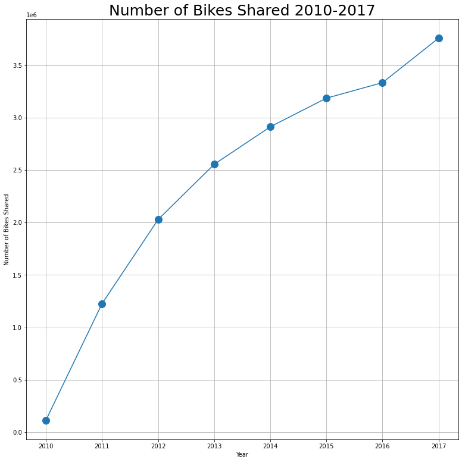

```python
# This is our y-axis for the graph, the years.
total_each_year = total_number_data['count'].tolist()
# This is the x-asix for the graph, the total number of bike shares.
year_arr = total_number_data.index.values.tolist()

fig, ax = plt.subplots(figsize=(13,13))

ax.plot(year_arr, total_each_year, marker='o', markersize=12)

params = {
    'axes.labelsize': 20,
    'axes.titlesize': 25,
    'xtick.labelsize': 15,
    'ytick.labelsize': 15
}

plt.rcParams.update(params)
ax.set_xlabel("Year")
ax.set_ylabel("Number of Bikes Shared")
ax.set_title("Number of Bikes Shared 2010-2017")
ax.grid(True)
```

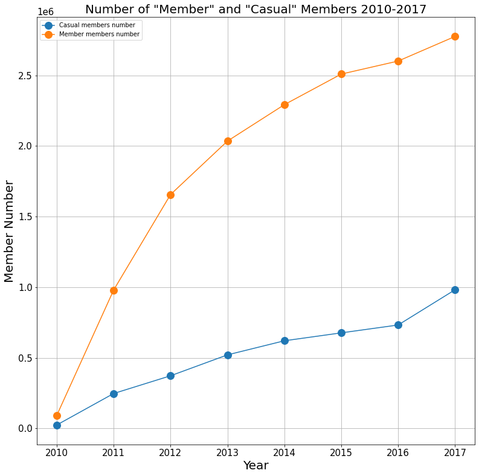

```python
### Graphing the number of "registered" members and "casual" members between 2010-2017 ###

member_data = graph_data.groupby(['Member type','Year']).sum()
member_data.reset_index(inplace=True)

# Getting the sub-dataframes for all "Casual" and "Member" members
casual_df = member_data.loc[member_data['Member type']=='Casual']
member_df = member_data.loc[member_data['Member type']=='Member']

# Gettomg the y axis for both dfs
casual_number = casual_df['count'].tolist()
member_number = member_df['count'].tolist()


# Plotting!
fig, ax = plt.subplots(figsize=(13,13))

ax.plot(year_arr, casual_number, marker='o', markersize=12, label='Casual members number')
ax.plot(year_arr, member_number, marker='o', markersize=12, label='Member members number')

params = {
    'axes.labelsize': 20,
    'axes.titlesize': 25,
    'xtick.labelsize': 15,
    'ytick.labelsize': 15
}

plt.rcParams.update(params)
ax.set_xlabel("Year")
ax.set_ylabel("Member Number")
ax.set_title("Number of \"Member\" and \"Casual\" Members 2010-2017", fontsize=20)
ax.legend()
ax.grid(True)
```

```python
### Finding the top5 most used stations' locations ###

# Grouping by "Start station" and summing it gives us the total # of use of each station
location_data = graph_data.groupby(['Start station']).sum()
# Sorting the value using "count"
location_data.sort_values(['count'], inplace=True, ascending=False)
# Now this is the top 5 most used stations! Let's get their address!
location_data.head()
```

| Start station | Duration | Start station number | End station number | Year | Hour | Month | count |
| --- | --- | --- | --- | --- | --- | --- | --- |
| Columbus Circle / Union Station | 339138998 | 13042368759 | 12977512349 | 830804930 | 5574461 | 2831625 | 412433 |
| Massachusetts Ave & Dupont Circle NW | 406117165 | 12263191200 | 12279091712 | 791557230 | 5705730 | 2697137 | 393051 |
| Lincoln Memorial | 680530968 | 9445354892 | 9443123711 | 608911157 | 4464580 | 2084105 | 302174 |
| 15th & P St NW | 222371041 | 9093125837 | 9107326097 | 586967543 | 4238622 | 1987895 | 291437 |
| Jefferson Dr & 14th St SW | 660807122 | 8772064051 | 8782086011 | 565658344 | 4152942 | 1902129 | 280733 |

Note: Below I got the latitude and longtitude of each bike station using google map. I simply typed "Capital BikeShare" and added the Start Station names on google map, and right clicked to get the latitude and longtitude.

```python
# Lat and Long for the top 5 most used stations
locations = [
    (38.897360798890546, -77.00497291534164),
    (38.91035649593718, -77.04444795393437),
    (38.88844705286185, -77.04947941716027),
    (38.910611112270495, -77.03397431961461),
    (38.88870523443909, -77.03239613267372)
            ]
```

```python
# Now we will put them on a map using a library called folium!
import folium
```

```python
# Initializing the map
map_osm = folium.Map(location=[38.899, -77.03], zoom_start=13.5)

# Adding the top 5 stations as red markers on the map
for location in locations:
    folium.Marker(location=location, icon=folium.Icon(color='red')).add_to(map_osm)

# Now this is the top five most used stations!
map_osm
```

Make this Notebook Trusted to load map: File -> Trust Notebook

[interactive chart not shown]

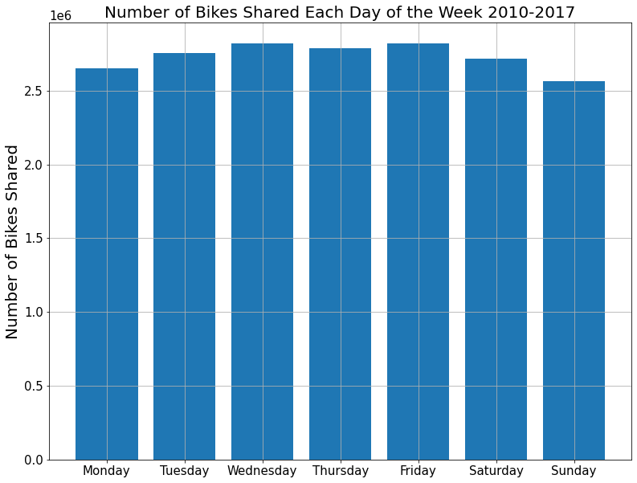

```python
### Now we are graphing the number of bikes shared on each day of the week ###

# Because we are graphing each day of the week, we are grouping by 'Day'
day_data = graph_data.groupby(['Day']).sum()
# Resetting index to access weekdays easily!
day_data.reset_index(inplace=True)

# Setting data in order by day of week
cats = [ 'Monday', 'Tuesday', 'Wednesday', 'Thursday', 'Friday', 'Saturday', 'Sunday']
day_data = day_data.groupby(['Day']).sum().reindex(cats)
day_data.reset_index(inplace=True)

# We are getting our index for bar plot, which is the days in a week.
day_index = day_data['Day'].tolist()
# And the total count for each day of the week.
count = day_data['count'].tolist()

# Plotting!
fig, ax = plt.subplots(figsize=(13,10))

ax.bar(x=day_index, height=count)
ax.grid()
ax.set_ylabel('Number of Bikes Shared')
ax.set_title("Number of Bikes Shared Each Day of the Week 2010-2017", fontsize=20)
```

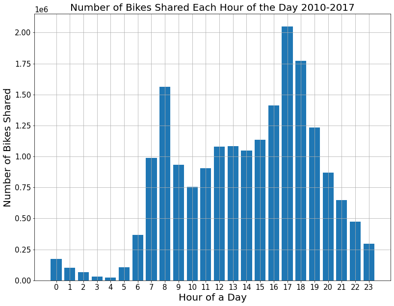

```python
### Now we are graphing the number of bikes shared on each hour of the day ###

# Because we are graphing each hour, we are grouping by 'hour'
hour_data = graph_data.groupby(['Hour']).sum()
hour_data.reset_index(inplace=True)

# Just like we did above, we are getting the index
hour_index = hour_data['Hour'].tolist()
# And the values associated with each index
hour_count = hour_data['count'].tolist()

# Plotting!
fig, ax = plt.subplots(figsize=(13,10))

ax.bar(x=hour_index, height=hour_count)
ax.set_ylabel('Number of Bikes Shared')
ax.set_xlabel('Hour of a Day')
ax.set_xticks(hour_index)
ax.grid()
ax.set_title("Number of Bikes Shared Each Hour of the Day 2010-2017", fontsize=20)
```

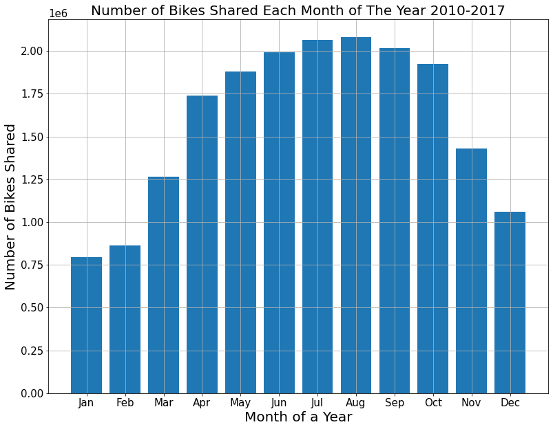

```python
### Now we are graphing the number of bikes shared on each month of the year ###

# Because we are graphing each month, we are grouping by 'month'
month_data = graph_data.groupby(['Month']).sum()
month_data.reset_index(inplace=True)

# Exactly like above...
month_index = ['Jan', 'Feb', 'Mar', 'Apr', 'May', 'Jun',
               'Jul', 'Aug', 'Sep', 'Oct', 'Nov', 'Dec']
month_count = month_data['count'].tolist()

# Plotting!
fig, ax = plt.subplots(figsize=(13,10))

ax.bar(x=month_index, height=month_count)
ax.set_ylabel('Number of Bikes Shared')
ax.set_xlabel('Month of a Year')
ax.set_xticks(month_index)
ax.grid()
ax.set_title("Number of Bikes Shared Each Month of The Year 2010-2017", fontsize=20)
```

### Predicting the Growth of The Bike Sharing Service in DC

In this part of the tutorial, we will use linear and non-linear models to predict the growth rate of this bike-sharing service in DC. We will test out models with 2018, 2019, and 2020 data!

Tools:

- ax.scatter() function, which returns a scatter plot with given dependent and independent variables. We use a scatter plot so it is easy to fit a linear/non-linear regression. More information can be found here:https://matplotlib.org/3.5.0/api/_as_gen/matplotlib.axes.Axes.scatter.html More info on linear regression in python can be found here: https://realpython.com/linear-regression-in-python/
- sklearn.linear_model.LinearRegression function is an easy-to-use Python library that provides linear regression models. More information can be found here: https://scikit-learn.org/stable/modules/generated/sklearn.linear_model.LinearRegression.html
- This is an example code on a simple linear regression model, check it out if you are interested! https://scikit-learn.org/stable/auto_examples/linear_model/plot_ols.html
- sklearn.preprocessing.PolynomialFeatures. This is for our high-degrees, non-linear models. Check more information out here: https://scikit-learn.org/stable/modules/generated/sklearn.preprocessing.PolynomialFeatures.html

First let’s import our data for 2018, 2019, and 2020. We will follow the same steps as at the beginning of the tutorial.

```python
# We are again reading all .csv files from our data folder. This time we will not be printing the name of the files
# because starting 2018, CapitalBikeShare started having monthly data of the year in one file. Showing all file names
# for the three years would resulted in printing 3 * 12 = 36 lines of names.
file_names = ["./2018_2020_data/" + f for f in os.listdir('./2018_2020_data') if f.endswith('.csv')]
data_18_20 = pd.concat(map(pd.read_csv, file_names))
```

```python
data_18_20.head()
```

|  | Duration | Start date | End date | Start station number | Start station | End station number | End station | Bike number | Member type | ride_id | ... | ended_at | start_station_name | start_station_id | end_station_name | end_station_id | start_lat | start_lng | end_lat | end_lng | member_casual |
| --- | --- | --- | --- | --- | --- | --- | --- | --- | --- | --- | --- | --- | --- | --- | --- | --- | --- | --- | --- | --- | --- |
| 0 | 552.0 | 2018-01-01 00:05:06 | 2018-01-01 00:14:18 | 31104.0 | Adams Mill & Columbia Rd NW | 31400.0 | Georgia & New Hampshire Ave NW | W00886 | Member | NaN | ... | NaN | NaN | NaN | NaN | NaN | NaN | NaN | NaN | NaN | NaN |
| 1 | 1282.0 | 2018-01-01 00:14:30 | 2018-01-01 00:35:53 | 31321.0 | 15th St & Constitution Ave NW | 31321.0 | 15th St & Constitution Ave NW | W01435 | Casual | NaN | ... | NaN | NaN | NaN | NaN | NaN | NaN | NaN | NaN | NaN | NaN |
| 2 | 1265.0 | 2018-01-01 00:14:53 | 2018-01-01 00:35:58 | 31321.0 | 15th St & Constitution Ave NW | 31321.0 | 15th St & Constitution Ave NW | W21242 | Casual | NaN | ... | NaN | NaN | NaN | NaN | NaN | NaN | NaN | NaN | NaN | NaN |
| 3 | 578.0 | 2018-01-01 00:15:31 | 2018-01-01 00:25:09 | 31406.0 | 14th & Upshur St NW | 31103.0 | 16th & Harvard St NW | W21322 | Casual | NaN | ... | NaN | NaN | NaN | NaN | NaN | NaN | NaN | NaN | NaN | NaN |
| 4 | 372.0 | 2018-01-01 00:18:02 | 2018-01-01 00:24:15 | 31618.0 | 4th & East Capitol St NE | 31619.0 | Lincoln Park / 13th & East Capitol St NE | W00119 | Member | NaN | ... | NaN | NaN | NaN | NaN | NaN | NaN | NaN | NaN | NaN | NaN |

5 rows × 22 columns

```python
# We will transform the data from 2018-2020 in a copy called result_data!
result_data = data_18_20
```

Because we only care about the total number of data each year, we will only keep "Start data" column. So we can get the information about the year.

```python
# Only using "Start date" column
result_data = result_data[['Start date']]

# Converting "Start date" column's data to DateTime objects
pd.options.mode.chained_assignment = None
result_data['Start date'] = pd.to_datetime(result_data['Start date'])

# Setting the "count" column for counting number of data in a year
result_data['count'] = 1
# Setting the "Year" column to easily identify what year a data is
result_data['year'] = pd.DatetimeIndex(result_data['Start date']).year
```

Now we have our "count" and "year" columns ready, we can simply group out data by year and call the .sum() function, which will add every data to count and show us the total number of data in every year, just like what we did above.

```python
result_data = result_data.groupby(['year']).sum()
```

Now, we can start building our linear and non-linear model for prediction, and test out modle using these three years of data!

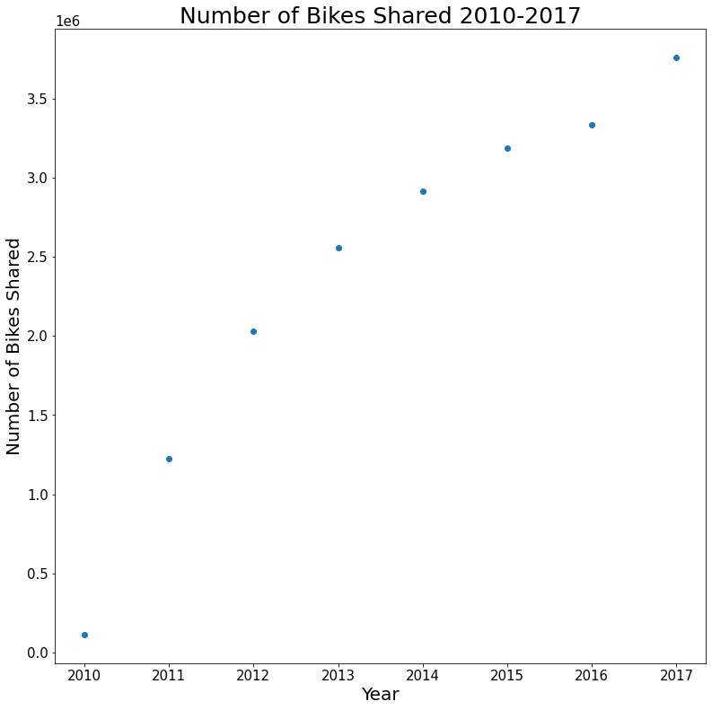

```python
### Getting the scatter plot for the number of bike shared from 2010-2017 ###

# Recall when we did the line plot for number of bike shared from 2010-2017, we will use
# the same data, only plotting them in a scatter plot this time!

# This is our y-values, the years.
total_each_year = total_number_data['count'].tolist()
# This is the x-values, the total number of bike shares.
year_arr = total_number_data.index.values.tolist()

# Plotting!
fig, ax = plt.subplots(figsize=(13,13))

ax.scatter(year_arr, total_each_year)

params = {
    'axes.labelsize': 20,
    'axes.titlesize': 25,
    'xtick.labelsize': 15,
    'ytick.labelsize': 15
}

plt.rcParams.update(params)
ax.set_xlabel("Year")
ax.set_ylabel("Number of Bikes Shared")
ax.set_title("Number of Bikes Shared 2010-2017")
```

Now we will first use a linear model to predict

```python
# For linear modle
from sklearn import linear_model

# fitting the linear regression
lm = linear_model.LinearRegression()

# year_2d is just the years but in 2d array form, e.g. [[2010],[2011],[2012],...,[2017]]
# the reason for this is that lm.fit, which gives us back a linear regression, can only take
# 2d array as a parameter!
year_2d = [ [year] for year in year_arr ]
# Same idea for each year's data, it has to be in a 2d array
total_2d = [ [data] for data in total_each_year ]
```

```python
### Getting our linear regression ###
lm.fit(year_2d, total_2d)
```

```
LinearRegression()
```

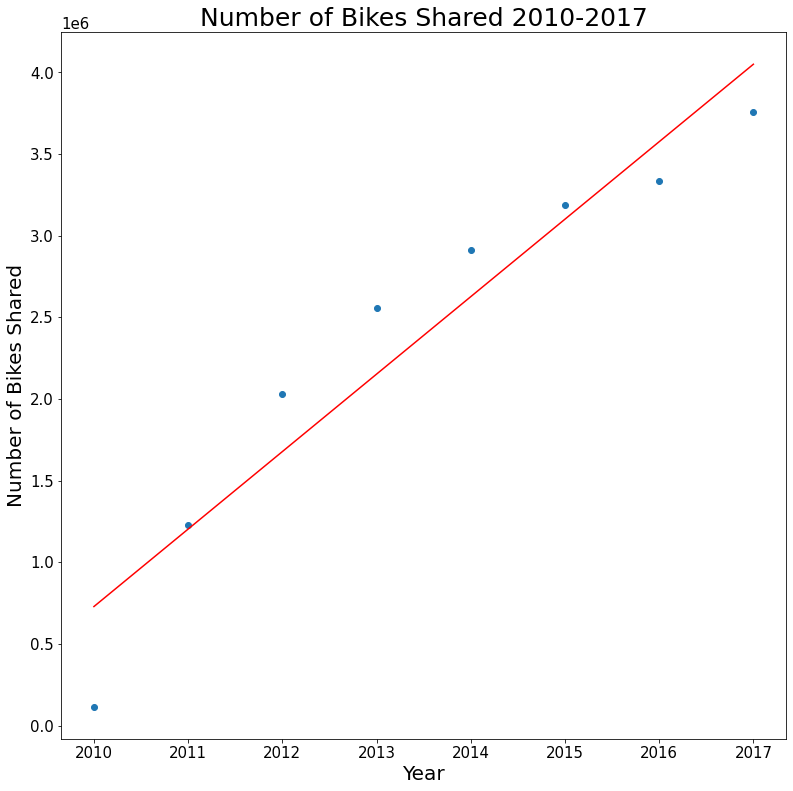

```python
# Plotting!
fig, ax = plt.subplots(figsize=(13,13))

ax.scatter(year_arr, total_each_year)

params = {
    'axes.labelsize': 20,
    'axes.titlesize': 25,
    'xtick.labelsize': 15,
    'ytick.labelsize': 15
}

plt.rcParams.update(params)
ax.set_xlabel("Year")
ax.set_ylabel("Number of Bikes Shared")
ax.set_title("Number of Bikes Shared 2010-2017")
# Plotting in the regression line!
ax.plot(year_2d, lm.predict(year_2d), color='red')
```

The line visually looks good, but we can statistically see how well the line fits the data by looking at its R^2 value. When the R^2 value is 1 that means our linear line fits the data perfectly well (e.g. every point is on the line), and when R^2 value is 0 that means the model is nonsense and there is nothing predictive about the model :( So let's see our R^2!

```python
print(lm.score(year_2d,total_2d))
```

```
0.9134884865740657
```

0.91 is really good! Imagine getting a 91 in any CS class, right? Usually, it’s an A! And so is our model! Let's look at our model's prediction on 2018-2020 compare to the actual number!

```python
# Prediction:
predicted_2018 = lm.predict([[2018]])[0][0]
predicted_2019 = lm.predict([[2019]])[0][0]
predicted_2020 = lm.predict([[2020]])[0][0]

print("Our linear model predicts that in 2018 there will be %d bike shares, \
in 2019 there will be %d bike shares, and in 2020 there will be %d bike shares!" % (int(predicted_2018), int(predicted_2019), int(predicted_2020)))
```

```
Our linear model predicts that in 2018 there will be 4525061 bike shares, in 2019 there will be 4999585 bike shares, and in 2020 there will be 5474109 bike shares!
```

Let's now look at the actual number of bike shares!

```python
result_data
```

| year | count |
| --- | --- |
| 2018.0 | 3542684 |
| 2019.0 | 3398417 |
| 2020.0 | 537400 |

```python
print("As we can see, the actual data is that in 2018 there is %d bike shares, in 2019 %d, and \
in 2020 %d. Our linear model predicted 2018 by %.2f percent off, 2019 by %.2f percent off, and 2020 by %.2f percent off." % \
      (3542684, 3398417, 537400, (predicted_2018-3542684)/3542684*100, (predicted_2019-3398417)/3398417*100, (predicted_2020-537400)/537400*100))
```

```
As we can see, the actual data is that in 2018 there is 3542684 bike shares, in 2019 3398417, and in 2020 537400. Our linear model predicted 2018 by 27.73 percent off, 2019 by 47.12 percent off, and 2020 by 918.63 percent off.
```

What happened?

Let’s talk about 2020 first. As we can see there is significantly less data for the year 2020 compared to 2018 and 2019. Therefore it is clear that something happened in the year 2020 (we all know it's COVID…), and that the amount of data in the year 2020, does not apply to our linear model, or even any predictive model we make.

As for the years 2018 and 2019, we will next try using nonlinear models to see if we can get the prediction closer to reality.

```python
### Let's try poly line prediction! ###

# This is for poly line!
from sklearn.preprocessing import PolynomialFeatures
```

```
Our R^2 score for degree 2 polynomial model is 0.9871
```

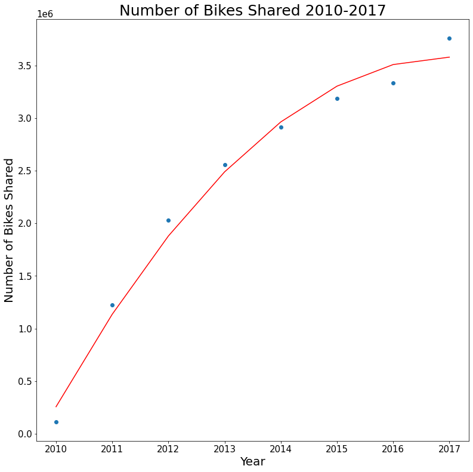

```python
# Plotting!

degree2_poly = PolynomialFeatures(degree=2)
degree2_years = degree2_poly.fit_transform(year_2d)
lm.fit(degree2_years, total_2d)

fig, ax = plt.subplots(figsize=(13,13))

ax.scatter(year_arr, total_each_year)

params = {
    'axes.labelsize': 20,
    'axes.titlesize': 25,
    'xtick.labelsize': 15,
    'ytick.labelsize': 15
}

plt.rcParams.update(params)
ax.set_xlabel("Year")
ax.set_ylabel("Number of Bikes Shared")
ax.set_title("Number of Bikes Shared 2010-2017")
# Plotting in the regression line!
ax.plot(year_2d, lm.predict(degree2_years), color='red')
print("Our R^2 score for degree 2 polynomial model is %.4f" \
      % (lm.score(degree2_years,total_2d)))
```

This time degree 2 polynomial model gives us an even better R^2 score of 0.9871! This time we get a straight-up A+ for our model ;). Let’s again see how it predicts the years 2018 and 2019!

```python
# Getting our prediction for 2018 and 2019
year_2018_2019 = [[2018], [2019]]
degree2_2018_2019 = degree2_poly.fit_transform(year_2018_2019)
# Making them as integers!
d2_predicted_2018 = int(lm.predict(degree2_2018_2019)[0][0])
d2_predicted_2019 = int(lm.predict(degree2_2018_2019)[1][0])
```

```python
print("The actual data is that in 2018 there is %d bike shares, and in 2019 %d. Our degree 2 poly model predicted 2018 by %.2f percent off, and 2019 by %.2f percent off." % \
      (3542684, 3398417, abs(d2_predicted_2018-3542684)/3542684*100, abs(d2_predicted_2019-3398417)/3398417*100))
```

```
The actual data is that in 2018 there is 3542684 bike shares, and in 2019 3398417. Our degree 2 poly model predicted 2018 by 0.78 percent off, and 2019 by 2.42 percent off.
```

This is really, really good! Our degree 2 polynomial model predicts the year 2018 and 2019 almost perfectly! And the reason for this might be that the growth rate of the number of people using the bike-sharing service is decreasing, therefore our growth model is an increasing line with a decreasing rate (e.g. a growing, concaving down graph).

Now let’s see what the line look like when we add in the year 2018 and 2019!

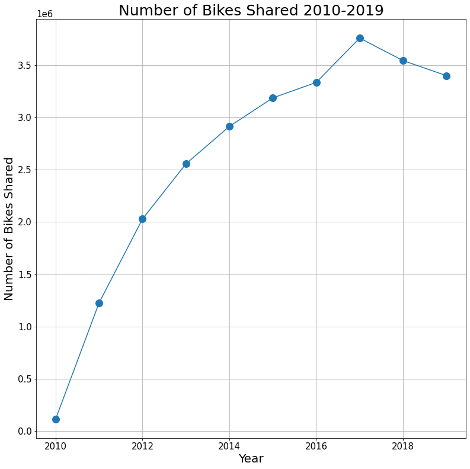

```python
### Plotting data from 2010-2019 ###

fig, ax = plt.subplots(figsize=(13,13))

# Adding the two years and data of the two years
year_arr.append(2018)
year_arr.append(2019)
total_each_year.append(3542684)
total_each_year.append(3398417)


ax.plot(year_arr, total_each_year, marker='o', markersize=12)

params = {
    'axes.labelsize': 20,
    'axes.titlesize': 25,
    'xtick.labelsize': 15,
    'ytick.labelsize': 15
}

plt.rcParams.update(params)
ax.set_xlabel("Year")
ax.set_ylabel("Number of Bikes Shared")
ax.set_title("Number of Bikes Shared 2010-2019")
ax.grid(True)
```

### Conclusion

This is the last part of the tutorial. We will put everything together and try to draw insights from our data!

As we can see from the graphs, the first three years, 2010-2013 have the fastest growth rate in terms of the number of bikes shared. Now that the growth rate is slowing down, probably because of the number of bike stations and the number of bikes is approaching the saturation point, meaning that a group of frequent users has formed, and there will be fewer new users in the future.

The statement above can also be supported by the graph titled “Number of ‘Member’ and ‘Casual’ Member 2010-2017.” “Member” indicates Annual Member, 30-Day Member, or Day Key Member, and “Casual” means Single Trip. We see a rapid increase in the number of “Member” members, meaning that an increasing amount of people are using the bike-sharing services frequently!

As for the map showing us the top 5 most used bike stations. We see that three out of five stations are located around the tourist area of D.C. (from Lincoln Memorial to Washington Union Station). This is easily explainable since more people are visiting around this area, people would use these services more in order to get around faster.

Surprisingly, the number of bikes shared each day does not vary that much across weekdays. From the bar plot named “Number of Bike Shared Each Day of the Week 2010-2017”, we even see that on Saturday, there are more bike shares than on Monday. Maybe this is because of people taking a weekend trip/break in D.C. would commute around the city using these sharing bikes. Overall, the number of bikes shared is fairly consistent across weekdays.

What is not surprising, is the number of bikes shared each hour across the day. Based on the bar plot titled “Number of Bikes Shared Each Hour of the Day 2010-2017,” we that the peak usage occurs in the morning, around 08:00, and in the evening, around 17:00, and during the day time the number of bikes shared is significantly higher during night time. This is intuitive since the peak usages are when people go to work in the morning and people go off from work in the evening.